# Stefano Biguzzi - HW #1

**Principles of Data Visualization and Introduction to ggplot2**

I have provided you with data about the 5,000 fastest growing companies in the US, as compiled by Inc. magazine. lets read this in:

```r
inc <- read.csv("https://raw.githubusercontent.com/charleyferrari/CUNY_DATA_608/master/module1/Data/inc5000_data.csv", header= TRUE)
```

And lets preview this data:

```r
head(inc)
```

```
##   Rank                         Name Growth_Rate   Revenue
## 1    1                         Fuhu      421.48 1.179e+08
## 2    2        FederalConference.com      248.31 4.960e+07
## 3    3                The HCI Group      245.45 2.550e+07
## 4    4                      Bridger      233.08 1.900e+09
## 5    5                       DataXu      213.37 8.700e+07
## 6    6 MileStone Community Builders      179.38 4.570e+07
##                       Industry Employees         City State
## 1 Consumer Products & Services       104   El Segundo    CA
## 2          Government Services        51     Dumfries    VA
## 3                       Health       132 Jacksonville    FL
## 4                       Energy        50      Addison    TX
## 5      Advertising & Marketing       220       Boston    MA
## 6                  Real Estate        63       Austin    TX
```

```r
summary(inc)
```

```
##       Rank          Name            Growth_Rate         Revenue
##  Min.   :   1   Length:5001        Min.   :  0.340   Min.   :2.000e+06
##  1st Qu.:1252   Class :character   1st Qu.:  0.770   1st Qu.:5.100e+06
##  Median :2502   Mode  :character   Median :  1.420   Median :1.090e+07
##  Mean   :2502                      Mean   :  4.612   Mean   :4.822e+07
##  3rd Qu.:3751                      3rd Qu.:  3.290   3rd Qu.:2.860e+07
##  Max.   :5000                      Max.   :421.480   Max.   :1.010e+10
##
##    Industry           Employees           City              State
##  Length:5001        Min.   :    1.0   Length:5001        Length:5001
##  Class :character   1st Qu.:   25.0   Class :character   Class :character
##  Mode  :character   Median :   53.0   Mode  :character   Mode  :character
##                     Mean   :  232.7
##                     3rd Qu.:  132.0
##                     Max.   :66803.0
##                     NA's   :12
```

Think a bit on what these summaries mean. Use the space below to add some more relevant non-visual exploratory information you think helps you understand this data:

Summary means by industry

```r
ind_mean <- aggregate(inc[,c(3,4,6)],  by = list(inc$Industry), FUN = mean, na.rm = T)
names(ind_mean)[1] <- 'Industry'
ind_mean
```

```
##                        Industry Growth_Rate   Revenue  Employees
## 1       Advertising & Marketing    6.225478  16528662   84.35456
## 2  Business Products & Services    3.518485  54705187  244.49375
## 3             Computer Hardware    4.089773 270129545  220.77273
## 4                  Construction    3.366684  70450802  155.60963
## 5  Consumer Products & Services    8.776108  73676847  223.96059
## 6                     Education    3.642651  13726506   92.59036
## 7                        Energy    9.603303 126344954  242.54128
## 8                   Engineering    1.984324  34222973  276.14865
## 9        Environmental Services    2.068039  51741176  199.11765
## 10           Financial Services    5.435308  50580385  183.43462
## 11              Food & Beverage    3.636565  98559542  510.93798
## 12          Government Services    7.238168  29748020  129.62871
## 13                       Health    4.856394  50319437  232.85311
## 14              Human Resources    3.300459  47173980 1158.06122
## 15                    Insurance    2.008400  46758000  146.78000
## 16                  IT Services    3.331814  28214598  140.42077
## 17   Logistics & Transportation    4.339226  95745161  259.70130
## 18                Manufacturing    2.295391  49546875  172.32157
## 19                        Media    4.374074  32266667  176.51852
## 20                  Real Estate    7.746667  30892708  198.87368
## 21                       Retail    6.184729  50529064  182.60099
## 22                     Security    3.388904  52230137  562.45205
## 23                     Software    5.020643  23802924  150.32845
## 24           Telecommunications    2.883721  56855814  242.85039
## 25         Travel & Hospitality    2.353065  47283871  371.53226
```

Summary medians by industry

```r
ind_med <- aggregate(inc[,c(3,4,6)],  by = list(inc$Industry), FUN = median, na.rm = T)
names(ind_med)[1] <- 'Industry'
ind_med
```

```
##                        Industry Growth_Rate  Revenue Employees
## 1       Advertising & Marketing       1.610  7900000      37.0
## 2  Business Products & Services       1.095  9850000      49.0
## 3             Computer Hardware       1.045 22350000      45.5
## 4                  Construction       1.300 14000000      47.0
## 5  Consumer Products & Services       1.820  9400000      34.0
## 6                     Education       1.200  6800000      44.0
## 7                        Energy       2.080 29400000      70.0
## 8                   Engineering       1.350 12100000      64.0
## 9        Environmental Services       1.410 12500000      67.0
## 10           Financial Services       1.485 15550000      70.0
## 11              Food & Beverage       1.320 18600000      65.0
## 12          Government Services       2.110 11450000      71.0
## 13                       Health       1.570 11400000      71.0
## 14              Human Resources       1.520 11450000      71.5
## 15                    Insurance       1.200 12650000      53.0
## 16                  IT Services       1.380 10000000      57.0
## 17   Logistics & Transportation       1.320 20800000      50.0
## 18                Manufacturing       1.070 11900000      49.0
## 19                        Media       1.940  7600000      34.0
## 20                  Real Estate       2.070 12800000      49.0
## 21                       Retail       1.760  8200000      31.0
## 22                     Security       1.540 12300000      77.0
## 23                     Software       1.715  8700000      69.0
## 24           Telecommunications       1.280 16600000      65.0
## 25         Travel & Hospitality       1.135  8600000      38.0
```

Summary mean by state

```r
state_mean <- aggregate(inc[,c(3,4,6)],  by = list(inc$State), FUN = mean, na.rm = T)
names(state_mean)[1] <- 'State'
state_mean
```

```
##    State Growth_Rate   Revenue  Employees
## 1     AK    4.805000 171500000 1264.00000
## 2     AL    2.407451  25907843  125.35294
## 3     AR    1.670000   8333333   55.11111
## 4     AZ    4.616700  55015000  342.81000
## 5     CA    5.897489  33463481  230.31286
## 6     CO    4.952015  31270149  198.78195
## 7     CT    4.994600  49486000  139.78000
## 8     DC    8.298140  76344186  219.54762
## 9     DE    2.420000  42300000 4284.00000
## 10    FL    5.846099  37625177  217.09574
## 11    GA    3.523538  30510849  163.72512
## 12    HI    6.792857  99485714   88.71429
## 13    IA    1.761071 123142857  405.14286
## 14    ID    2.645294 231523529  342.17647
```

[output cut: 38 more lines]

Summary median by state

```r
state_med <- aggregate(inc[,c(3,4,6)],  by = list(inc$State), FUN = median, na.rm = T)
names(state_med)[1] <- 'State'
state_med
```

```
##    State Growth_Rate   Revenue Employees
## 1     AK       4.805 171500000    1264.0
## 2     AL       1.320  10500000      55.0
## 3     AR       0.560   5700000      60.0
## 4     AZ       1.485   9250000      50.0
## 5     CA       1.670  10700000      45.0
## 6     CO       1.580  10800000      46.0
## 7     CT       1.340  11450000      48.0
## 8     DC       1.980   8700000      41.0
## 9     DE       1.530   7800000      63.5
## 10    FL       1.610  10050000      49.5
## 11    GA       1.400  11400000      50.0
## 12    HI       2.650  15200000     100.0
## 13    IA       0.760  14650000      60.0
## 14    ID       1.340   8800000      36.0
```

[output cut: 38 more lines]

# Load Packages

```r
library(tidyverse)
# library(plyr)
library(cowplot)
```

## Question 1

Create a graph that shows the distribution of companies in the dataset by State (ie how many are in each state). There are a lot of States, so consider which axis you should use. This visualization is ultimately going to be consumed on a ‘portrait’ oriented screen (ie taller than wide), which should further guide your layout choices.

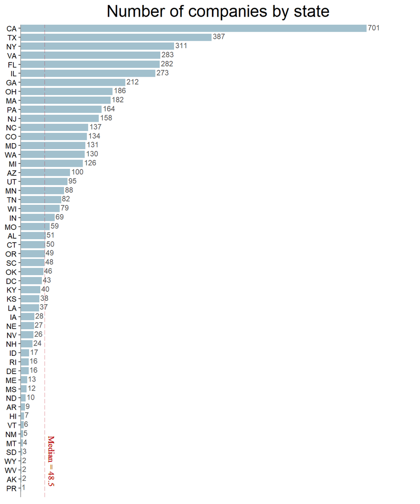

```r
ggplot(state_count, aes(x = count, y = reorder(State, count))) +
  geom_bar(stat = 'identity', fill='#A2C0CD', width = 0.8) +
  geom_text(aes(label = count), vjust = 0.3, hjust = -0.1,
            color = '#545454', size = 3) +
  geom_vline(
    xintercept = median(state_count$count),
    color = '#BF222C',
    size = 0.5,
    linetype="longdash",
    alpha = 0.3) +
  geom_text(
    aes(x = median(count),y = 0,
        label = paste("Median",round(median(count),1),sep = " = ")),
    size=3.5, angle=270, vjust=-0.7, hjust=1.2, color = '#BF222C',
    family="serif") +
  scale_x_continuous(expand = c(0,0),limits = c(0,800)) +
  scale_y_discrete(expand = c(0,0)) +
  ggtitle("Number of companies by state") +
  theme(
    panel.background = element_blank(),
    panel.grid = element_blank(),
    plot.title = element_text(size = 20,hjust=0.5),
    axis.line.y = element_line(size = 0.5, color  = '#999999'),
    axis.title.y = element_blank(),
    axis.text.y = element_text(size = 9, color = 'black'),
    axis.line.x = element_blank(),
    axis.ticks.x = element_blank(),
    axis.title.x = element_blank(),
    axis.text.x = element_blank())
```

## Quesiton 2

Lets dig in on the state with the 3rd most companies in the data set. Imagine you work for the state and are interested in how many people are employed by companies in different industries. Create a plot that shows the average and/or median employment by industry for companies in this state (only use cases with full data, use R’s `complete.cases()` function.) In addition to this, your graph should show how variable the ranges are, and you should deal with outliers.

[figure not shown]

```r
dplot.ny <-
  ggplot(third.most.companies, aes(x=Employees,
                                 y=reorder(Industry,EmpMedian))) +
  stat_boxplot(geom ='errorbar') +
  geom_boxplot(width = 0.7, fill = "lightgrey") +
  ggtitle("Boxplot of employees by industry in NY") +
  scale_x_log10(limits = c(1, 35000),
                expand = expansion(mult = c(0.01,0))) +
  ylab(element_blank()) +
  xlab("Employees (log scale)") +
  theme_minimal() +
  theme(axis.text.x = element_text(),
        panel.grid.major.x = element_blank(),
        panel.grid.minor.x = element_blank(),
        plot.title = element_text(size = 18, color = '#545454',hjust=0.5),
        axis.text.y = element_text(size=8,vjust=0.1))

mplot.ny <-
  ggplot(tmc_meds,aes(x=med, y=reorder(Industry,med))) +
  geom_bar(stat = 'identity', width = 0.8, color='lightgrey',alpha=0.5) +
  geom_text(aes(label = ceiling(med)), vjust = 0.4, hjust = -0.2,
                color = 'black', size = 3) +
  ggtitle("Median revenue per employee by industry") +
  scale_x_continuous(expand = c(0,0),limits=c(0,165))+
  theme_update() +
  theme(
    plot.title = element_text(size = 18, color = '#545454',hjust=0.5),
    panel.background = element_blank(),
    panel.grid = element_blank(),
    axis.title = element_blank(),
    axis.text.x = element_blank(),
    axis.ticks.x = element_blank(),
    axis.text.y = element_text(size=8,vjust=0.1))

plot_grid(dplot.ny,mplot.ny,nrow=2)
```

## Question 3

Now imagine you work for an investor and want to see which industries generate the most revenue per employee. Create a chart that makes this information clear. Once again, the distribution per industry should be shown.

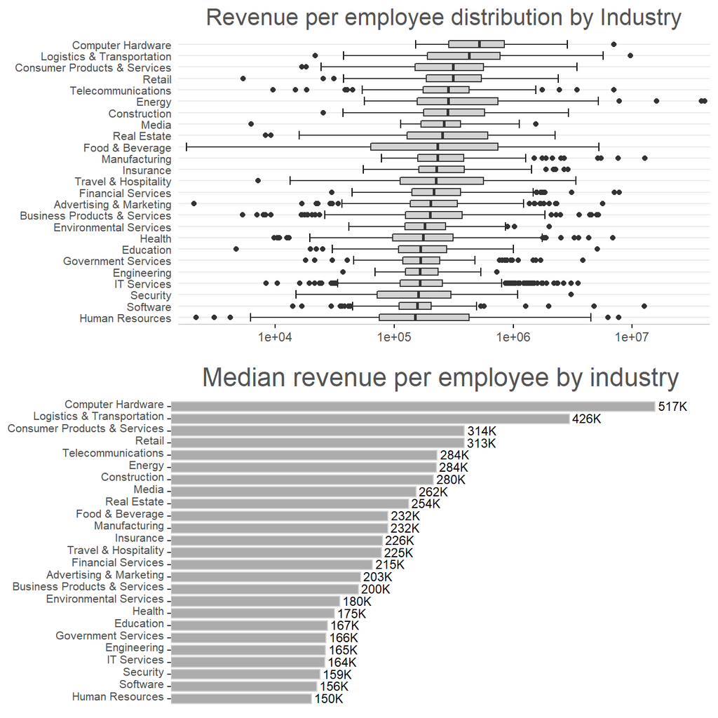

```r
dplot<-
  ggplot(inc_complete, aes(x = RevPerEmp,
                         y = reorder(Industry,RevPerEmp,median)))+
  stat_boxplot(geom ='errorbar') +
  geom_boxplot(width = 0.6, fill = "lightgrey")+
  scale_x_log10(limits = c(1700, 45000000),
                expand = expansion(mult = c(0.01,0)))+
  ggtitle("Revenue per employee distribution by Industry") +
  xlab(element_blank()) +
  ylab(element_blank()) +
  theme_minimal() +
  theme(axis.text.y = element_text(vjust = 0.5, hjust=1, size=8),
        axis.ticks.x = element_line(),
        axis.line.x = element_line(color = 'lightgrey'),
        panel.grid.major.x = element_blank(),
        panel.grid.minor.x = element_blank(),
        plot.title = element_text(size = 16, color = '#545454',hjust=0.5)
        )

mplot<-
  ggplot(employee.revenue,aes(x=revenue_per_employee/1000,
                            y=reorder(Industry,revenue_per_employee))) +
  geom_bar(stat = 'identity', width = 0.8, color='lightgrey',alpha=0.5) +
  geom_text(aes(label = paste0(ceiling(revenue_per_employee/1000),'K')),
            vjust = 0.4, hjust = -0.1, color = 'black', size = 3) +
  ggtitle("Median revenue per employee by industry") +
  scale_x_continuous(expand = c(0,0),limits=c(0,575))+
  theme_update() +
  theme(
    plot.title = element_text(size = 18, color = '#545454',hjust=0.5),
    panel.background = element_blank(),
    panel.grid = element_blank(),
    axis.title = element_blank(),
    axis.text.x = element_blank(),
    axis.ticks.x = element_blank(),
    axis.text.y = element_text(size=8,vjust=0.1))

plot_grid(dplot,mplot,nrow=2)
```